# Estimating Demographics and Other Characteristics for Custom Spatial Features – Example Workflow

Table 2: Water System Demographics

| WATER_SY_1 | WATER_SYST | GLOBALID | BOUNDARY_T | OWNER_TYPE | COUNTY | REGULATING | FEDERAL_CL | STATE_CLAS | SERVICE_CO | POPULATION | pop_est_total | pop_pct_difference | pop_est_asian | pop_est_black_or_african_american | pop_est_hispanic_or_latino | pop_est_native_american_or_alaska_native | pop_est_other_or_multiple | pop_est_pacific_islander | pop_est_white | pct_est_asian | pct_est_black_or_african_american | pct_est_hispanic_or_latino | pct_est_native_american_or_alaska_native | pct_est_other_or_multiple | pct_est_pacific_islander | pct_est_white | med_hh_income_est | geometry |
| --- | --- | --- | --- | --- | --- | --- | --- | --- | --- | --- | --- | --- | --- | --- | --- | --- | --- | --- | --- | --- | --- | --- | --- | --- | --- | --- | --- | --- |
| HOOD WATER MAINTENCE DIST [SWS] | CA3400101 | {36268DB3-9DB2-4305-A85A-2C3A85F20F34} | Water Service Area | L | SACRAMENTO | LPA64 - SACRAMENTO COUNTY | COMMUNITY | COMMUNITY | 82 | 100 | 1 | -99.00 | 0 | 0 | 1 | 0 | 0 | 0 | 0 | 0.00 | 0.00 | 59.49 | 0.00 | 1.78 | 0.00 | 38.74 | 51250 | MULTIPOLYGON (((-132703 403... |
| MC CLELLAN MHP | CA3400179 | {E3BF3C3E-D516-45B2-A5AD-6900F8D16715} | Water Service Area | P | SACRAMENTO | LPA64 - SACRAMENTO COUNTY | COMMUNITY | COMMUNITY | 199 | 700 | 310 | -55.71 | 70 | 33 | 32 | 0 | 17 | 0 | 158 | 22.53 | 10.70 | 10.46 | 0.00 | 5.51 | 0.00 | 50.79 | 37833 | MULTIPOLYGON (((-119809.2 7... |
| MAGNOLIA MUTUAL WATER | CA3400130 | {BADB48CD-AF05-4135-8FD5-9990BE415405} | Water Service Area | P | SACRAMENTO | LPA64 - SACRAMENTO COUNTY | COMMUNITY | COMMUNITY | 34 | 40 | 1 | -97.50 | 0 | 0 | 1 | 0 | 0 | 0 | 1 | 3.93 | 0.00 | 48.22 | 0.00 | 2.81 | 0.00 | 45.04 | 63076 | MULTIPOLYGON (((-137015.5 3... |
| KORTHS PIRATES LAIR | CA3400135 | {7A556C0E-57E2-499A-9B87-B5707C837DA8} | Water Service Area | P | SACRAMENTO | LPA64 - SACRAMENTO COUNTY | COMMUNITY | COMMUNITY | 64 | 150 | 0 | -100.00 | 0 | 0 | 0 | 0 | 0 | 0 | 0 | 0.00 | 2.75 | 5.19 | 0.00 | 2.60 | 0.00 | 89.47 | 28182 | MULTIPOLYGON (((-137297.1 1... |
| EL DORADO MOBILE HOME PARK | CA3400121 | {23B9391F-B6E7-44CE-A0EA-C2EE522857BF} | Water Service Area | P | SACRAMENTO | LPA64 - SACRAMENTO COUNTY | COMMUNITY | COMMUNITY | 128 | 256 | 145 | -43.36 | 14 | 28 | 85 | 0 | 5 | 0 | 12 | 10.03 | 19.48 | 58.72 | 0.00 | 3.42 | 0.00 | 8.36 | 34669 | MULTIPOLYGON (((-124533.7 5... |
| RIVER'S EDGE MARINA & RESORT | CA3400107 | {F56E068C-AE1B-4C68-A2AF-F5058871E4E2} | Water Service Area | P | SACRAMENTO | LPA64 - SACRAMENTO COUNTY | COMMUNITY | COMMUNITY | 83 | 150 | 0 | -100.00 | 0 | 0 | 0 | 0 | 0 | 0 | 0 | 0.00 | 2.75 | 5.19 | 0.00 | 2.60 | 0.00 | 89.47 | 28182 | MULTIPOLYGON (((-141320.7 1... |
| LAGUNA VILLAGE RV PARK | CA3400397 | {5184D6CC-8084-494D-BD81-B0009F76F1FD} | Water Service Area | P | SACRAMENTO | LPA64 - SACRAMENTO COUNTY | COMMUNITY | COMMUNITY | 28 | 32 | 21 | -34.38 | 10 | 2 | 2 | 0 | 2 | 2 | 1 | 49.23 | 10.40 | 11.93 | 0.00 | 10.63 | 11.31 | 6.49 | 75625 | MULTIPOLYGON (((-122362.2 4... |
| SPINDRIFT MARINA | CA3400169 | {3B1EC48B-B696-452E-A769-99EF03DE955E} | Water Service Area | P | SACRAMENTO | LPA64 - SACRAMENTO COUNTY | COMMUNITY | COMMUNITY | 50 | 100 | 0 | -100.00 | 0 | 0 | 0 | 0 | 0 | 0 | 0 | 0.00 | 2.75 | 5.19 | 0.00 | 2.60 | 0.00 | 89.47 | 28182 | MULTIPOLYGON (((-140144.2 1... |
| SAC CITY MOBILE HOME COMMUNITY LP | CA3400296 | {BBEBB4AF-57F6-4CBA-9746-6EDDFF0BB86B} | Water Service Area | P | SACRAMENTO | LPA64 - SACRAMENTO COUNTY | COMMUNITY | COMMUNITY | 164 | 350 | 272 | -22.29 | 146 | 11 | 95 | 0 | 0 | 0 | 20 | 53.70 | 4.14 | 34.88 | 0.00 | 0.00 | 0.00 | 7.28 | 24757 | MULTIPOLYGON (((-124542.8 5... |
| ORANGE VALE WATER COMPANY | CA3410016 | {E7FB0496-8E98-4C1C-B073-40B7F2308EE3} | Water Service Area | P | SACRAMENTO | DISTRICT 09 - SACRAMENTO | COMMUNITY | COMMUNITY | 5684 | 18005 | 17664 | -1.89 | 639 | 254 | 2762 | 117 | 1337 | 86 | 12471 | 3.61 | 1.44 | 15.63 | 0.66 | 7.57 | 0.48 | 70.60 | 90240 | MULTIPOLYGON (((-104831.8 7... |
| GOLDEN STATE WATER CO. - CORDOVA | CA3410015 | {D09864D9-0038-4D96-AA06-F1D0F4207324} | Water Service Area | P | SACRAMENTO | DISTRICT 09 - SACRAMENTO | COMMUNITY | COMMUNITY | 14798 | 44928 | 48558 | 8.08 | 5760 | 3910 | 8800 | 70 | 2705 | 218 | 27094 | 11.86 | 8.05 | 18.12 | 0.14 | 5.57 | 0.45 | 55.80 | 97284 | MULTIPOLYGON (((-105024.5 6... |
| HOLIDAY MOBILE VILLAGE | CA3400335 | {31419106-A98A-447B-AAF5-674FA6C8D17F} | Water Service Area | P | SACRAMENTO | LPA64 - SACRAMENTO COUNTY | COMMUNITY | COMMUNITY | 115 | 200 | 54 | -73.00 | 16 | 2 | 26 | 0 | 4 | 0 | 6 | 29.60 | 4.33 | 47.39 | 0.00 | 7.03 | 0.00 | 11.65 | 34806 | MULTIPOLYGON (((-123885.3 5... |
| SOUTHWEST TRACT W M D [SWS] | CA3400156 | {0B3A9348-87E2-475F-B9EB-8A0E7658CA58} | Water Service Area | L | SACRAMENTO | LPA64 - SACRAMENTO COUNTY | COMMUNITY | COMMUNITY | 33 | 150 | 145 | -3.33 | 56 | 22 | 35 | 2 | 7 | 1 | 22 | 38.78 | 15.27 | 24.11 | 1.43 | 4.59 | 0.66 | 15.16 | 43780 | MULTIPOLYGON (((-125846.9 5... |
| CARMICHAEL WATER DISTRICT | CA3410004 | {2E757010-FDE6-4A95-9D60-16E621A3CEAC} | Water Service Area | L | SACRAMENTO | DISTRICT 09 - SACRAMENTO | COMMUNITY | COMMUNITY | 11704 | 37897 | 39321 | 3.76 | 3315 | 1658 | 6381 | 96 | 2225 | 384 | 25261 | 8.43 | 4.22 | 16.23 | 0.24 | 5.66 | 0.98 | 64.24 | 99561 | MULTIPOLYGON (((-112199 690... |
| SCWA - ARDEN PARK VISTA | CA3410002 | {0FF3353C-7B37-44EC-A4B4-AB9A9D8BF79C} | Water Service Area | L | SACRAMENTO | DISTRICT 09 - SACRAMENTO | COMMUNITY | COMMUNITY | 3043 | 10035 | 7927 | -21.01 | 429 | 189 | 889 | 1 | 318 | 10 | 6092 | 5.41 | 2.38 | 11.22 | 0.01 | 4.01 | 0.13 | 76.85 | 151260 | MULTIPOLYGON (((-120321.1 6... |
| SCWA - LAGUNA/VINEYARD | CA3410029 | {0D088865-F70E-43D5-899E-1B988AB097B9} | Water Service Area | L | SACRAMENTO | DISTRICT 09 - SACRAMENTO | COMMUNITY | COMMUNITY | 47411 | 172666 | 144910 | -16.07 | 48274 | 15371 | 28113 | 246 | 9585 | 2404 | 40916 | 33.31 | 10.61 | 19.40 | 0.17 | 6.61 | 1.66 | 28.24 | 116483 | MULTIPOLYGON (((-125203.9 4... |
| RIO COSUMNES CORRECTIONAL CENTER [SWS] | CA3400229 | {887BC04D-196C-4104-AF6A-DE128C8105D0} | Water Service Area | L | SACRAMENTO | LPA64 - SACRAMENTO COUNTY | COMMUNITY | COMMUNITY | 13 | 2800 | 26 | -99.07 | 1 | 6 | 6 | 1 | 3 | 1 | 9 | 4.29 | 20.94 | 24.56 | 3.18 | 9.49 | 2.02 | 35.52 | NA | MULTIPOLYGON (((-124028.8 3... |
| SCWA MATHER-SUNRISE | CA3410704 | {4E3FC0F8-4DB3-4B03-AAEB-C965EE668712} | Water Service Area | L | SACRAMENTO | DISTRICT 09 - SACRAMENTO | COMMUNITY | COMMUNITY | 6921 | 22839 | 17688 | -22.55 | 4384 | 1529 | 2470 | 38 | 1044 | 11 | 8213 | 24.78 | 8.64 | 13.96 | 0.21 | 5.90 | 0.06 | 46.43 | 139932 | MULTIPOLYGON (((-108416.1 5... |
| TUNNEL TRAILER PARK | CA3400192 | {896615F1-429B-4829-8D45-45AF249034BC} | Water Service Area | P | SACRAMENTO | LPA64 - SACRAMENTO COUNTY | COMMUNITY | COMMUNITY | 21 | 44 | 0 | -100.00 | 0 | 0 | 0 | 0 | 0 | 0 | 0 | 6.51 | 0.00 | 64.68 | 0.00 | 0.00 | 0.00 | 28.81 | 142932 | MULTIPOLYGON (((-136156.2 2... |
| IMPERIAL MANOR MOBILEHOME COMMUNITY | CA3400190 | {1F6AA119-33B3-4518-92C8-62843A00AE53} | Water Service Area | P | SACRAMENTO | LPA64 - SACRAMENTO COUNTY | COMMUNITY | COMMUNITY | 186 | 200 | 294 | 47.00 | 4 | 48 | 54 | 0 | 24 | 0 | 164 | 1.37 | 16.40 | 18.29 | 0.00 | 8.28 | 0.00 | 55.66 | 29096 | MULTIPOLYGON (((-115157 740... |
| CALAM - ISLETON | CA3410012 | {24CB80A8-8A7C-46E9-8413-3346147E7444} | Water Service Area | P | SACRAMENTO | DISTRICT 09 - SACRAMENTO | COMMUNITY | COMMUNITY | 480 | 1581 | 36 | -97.72 | 1 | 0 | 11 | 0 | 1 | 0 | 22 | 4.01 | 1.33 | 31.51 | 0.00 | 2.11 | 0.00 | 61.04 | 76889 | MULTIPOLYGON (((-138559.3 1... |
| FOLSOM, CITY OF - ASHLAND | CA3410030 | {C83A0A46-997F-44BF-9441-C2DBC0D706CF} | Water Service Area | L | SACRAMENTO | DISTRICT 09 - SACRAMENTO | COMMUNITY | COMMUNITY | 1079 | 3538 | 3913 | 10.60 | 187 | 54 | 328 | 1 | 308 | 1 | 3033 | 4.79 | 1.38 | 8.38 | 0.04 | 7.87 | 0.02 | 77.52 | 77740 | MULTIPOLYGON (((-100505 774... |
| LOCKE WATER WORKS CO [SWS] | CA3400138 | {66BAF16E-A801-4313-B7B8-FF4E564CA9F6} | Water Service Area | P | SACRAMENTO | LPA64 - SACRAMENTO COUNTY | COMMUNITY | COMMUNITY | 44 | 80 | 2 | -97.50 | 0 | 0 | 1 | 0 | 0 | 0 | 1 | 3.93 | 0.00 | 48.22 | 0.00 | 2.81 | 0.00 | 45.04 | 63076 | MULTIPOLYGON (((-131976.7 2... |
| DEL PASO MANOR COUNTY WATER DI | CA3410007 | {BC88D650-D07A-47DF-A872-CD3F6142791A} | Water Service Area | L | SACRAMENTO | DISTRICT 09 - SACRAMENTO | COMMUNITY | COMMUNITY | 1796 | 4520 | 5563 | 23.08 | 184 | 369 | 494 | 33 | 297 | 52 | 4135 | 3.30 | 6.63 | 8.88 | 0.59 | 5.34 | 0.94 | 74.33 | 93174 | MULTIPOLYGON (((-120274.9 6... |
| EAST WALNUT GROVE [SWS] | CA3400106 | {6E5DA14E-1740-4320-A7E4-FD9B48240017} | Water Service Area | L | SACRAMENTO | LPA64 - SACRAMENTO COUNTY | COMMUNITY | COMMUNITY | 166 | 300 | 5 | -98.33 | 0 | 0 | 2 | 0 | 0 | 0 | 2 | 3.93 | 0.00 | 48.22 | 0.00 | 2.81 | 0.00 | 45.04 | 63076 | MULTIPOLYGON (((-132506.6 2... |
| FOLSOM STATE PRISON | CA3410032 | {CFEFFCD1-76A3-4403-A906-D04B910D61C5} | Water Service Area | S | SACRAMENTO | DISTRICT 09 - SACRAMENTO | COMMUNITY | COMMUNITY | 2790 | 9703 | 4251 | -56.19 | 101 | 1783 | 1460 | 79 | 42 | 39 | 747 | 2.38 | 41.94 | 34.36 | 1.85 | 0.99 | 0.91 | 17.57 | 137307 | MULTIPOLYGON (((-99838.11 7... |
| CALAM - ARDEN | CA3410045 | {FC35B709-C658-4890-B64C-374368BFAC79} | Water Service Area | P | SACRAMENTO | DISTRICT 09 - SACRAMENTO | COMMUNITY | COMMUNITY | 1185 | 3908 | 10384 | 165.71 | 1288 | 2043 | 3474 | 19 | 722 | 33 | 2804 | 12.40 | 19.68 | 33.45 | 0.19 | 6.96 | 0.32 | 27.00 | 46057 | MULTIPOLYGON (((-123013.9 6... |
| EDGEWATER MOBILE HOME PARK | CA3400433 | {FA333DDB-BCD6-4D29-9D40-664577E929C9} | Water Service Area | P | SACRAMENTO | LPA64 - SACRAMENTO COUNTY | COMMUNITY | COMMUNITY | 22 | 40 | 0 | -100.00 | 0 | 0 | 0 | 0 | 0 | 0 | 0 | 0.00 | 2.75 | 5.19 | 0.00 | 2.60 | 0.00 | 89.47 | 28182 | MULTIPOLYGON (((-153715.8 7... |
| CALAM - LINCOLN OAKS | CA3410013 | {488DCE2C-6EEA-4377-8984-5833F5D03CDF} | Water Service Area | P | SACRAMENTO | DISTRICT 09 - SACRAMENTO | COMMUNITY | COMMUNITY | 14390 | 47487 | 41854 | -11.86 | 2179 | 1405 | 8930 | 157 | 2271 | 54 | 26857 | 5.21 | 3.36 | 21.34 | 0.38 | 5.43 | 0.13 | 64.17 | 74275 | MULTIPOLYGON (((-113737.5 7... |
| VIEIRA'S RESORT, INC | CA3400164 | {C8E1FF09-C1ED-47D9-BD1C-AE3C754ABA72} | Water Service Area | P | SACRAMENTO | LPA64 - SACRAMENTO COUNTY | COMMUNITY | COMMUNITY | 107 | 150 | 5 | -96.67 | 0 | 0 | 1 | 0 | 0 | 0 | 3 | 3.77 | 1.46 | 28.35 | 0.00 | 2.31 | 0.00 | 64.11 | 49028 | MULTIPOLYGON (((-143708.1 1... |
| FLORIN COUNTY WATER DISTRICT | CA3410033 | {7D72D48E-DB2F-4E79-B396-70EEB030D102} | Water Service Area | L | SACRAMENTO | DISTRICT 09 - SACRAMENTO | COMMUNITY | COMMUNITY | 2323 | 7831 | 10164 | 29.79 | 3035 | 1190 | 2890 | 4 | 585 | 852 | 1609 | 29.86 | 11.71 | 28.43 | 0.04 | 5.76 | 8.38 | 15.83 | 51381 | MULTIPOLYGON (((-119638.3 5... |
| WESTERNER MOBILE HOME PARK | CA3400331 | {5DF48C4F-72B2-40C9-B2F7-10F9FF855DCC} | Water Service Area | P | SACRAMENTO | LPA64 - SACRAMENTO COUNTY | COMMUNITY | COMMUNITY | 49 | 65 | 28 | -56.92 | 9 | 7 | 6 | 0 | 1 | 0 | 6 | 30.72 | 25.02 | 19.42 | 1.03 | 3.22 | 0.64 | 19.94 | 55221 | MULTIPOLYGON (((-122693.1 4... |
| EL DORADO WEST MHP | CA3400122 | {2667CD45-9C2C-41B7-A95B-2F343B570215} | Water Service Area | P | SACRAMENTO | LPA64 - SACRAMENTO COUNTY | COMMUNITY | COMMUNITY | 128 | 172 | 153 | -11.05 | 15 | 30 | 90 | 0 | 5 | 0 | 13 | 10.03 | 19.48 | 58.72 | 0.00 | 3.42 | 0.00 | 8.36 | 34669 | MULTIPOLYGON (((-124742.1 5... |
| TOKAY PARK WATER CO | CA3400172 | {D2908483-C728-45ED-9A75-BA27D6E66685} | Water Service Area | P | SACRAMENTO | LPA64 - SACRAMENTO COUNTY | COMMUNITY | COMMUNITY | 198 | 525 | 641 | 22.10 | 223 | 61 | 206 | 4 | 11 | 0 | 137 | 34.82 | 9.48 | 32.10 | 0.59 | 1.67 | 0.00 | 21.34 | 56262 | MULTIPOLYGON (((-122789.8 5... |
| LAGUNA DEL SOL INC | CA3400181 | {F64FE571-B7DD-4F78-BBCF-2057DA131C24} | Water Service Area | P | SACRAMENTO | LPA64 - SACRAMENTO COUNTY | COMMUNITY | COMMUNITY | 112 | 470 | 31 | -93.40 | 0 | 0 | 12 | 0 | 0 | 0 | 18 | 1.21 | 0.00 | 37.91 | 1.38 | 1.12 | 0.00 | 58.38 | 88938 | MULTIPOLYGON (((-105025.5 4... |
| OLYMPIA MOBILODGE | CA3410022 | {B1E1B46F-9300-473E-B970-1D739E004B14} | Water Service Area | P | SACRAMENTO | DISTRICT 09 - SACRAMENTO | COMMUNITY | COMMUNITY | 200 | 450 | 315 | -30.00 | 113 | 19 | 77 | 0 | 0 | 15 | 90 | 36.00 | 6.08 | 24.47 | 0.00 | 0.00 | 4.81 | 28.64 | 37000 | MULTIPOLYGON (((-123549.9 5... |
| GOLDEN STATE WATER CO - ARDEN WATER SERV | CA3410003 | {E2997C83-F848-48AF-8915-B45E6469AC6E} | Water Service Area | P | SACRAMENTO | DISTRICT 09 - SACRAMENTO | COMMUNITY | COMMUNITY | 1716 | 5125 | 6376 | 24.41 | 890 | 566 | 1501 | 0 | 773 | 1 | 2646 | 13.96 | 8.87 | 23.54 | 0.00 | 12.12 | 0.01 | 41.49 | 56056 | MULTIPOLYGON (((-120307.3 6... |
| ELEVEN OAKS MOBILE HOME COMMUNITY | CA3400191 | {AB99BC88-8951-414B-BA24-E873AF46C168} | Water Service Area | P | SACRAMENTO | LPA64 - SACRAMENTO COUNTY | COMMUNITY | COMMUNITY | 136 | 262 | 269 | 2.67 | 61 | 29 | 28 | 0 | 15 | 0 | 137 | 22.53 | 10.70 | 10.46 | 0.00 | 5.51 | 0.00 | 50.79 | 37833 | MULTIPOLYGON (((-119816 721... |
| CALAM - ANTELOPE | CA3410031 | {AE6C5C3E-859C-4CD7-B3DF-5913A953F8F9} | Water Service Area | P | SACRAMENTO | DISTRICT 09 - SACRAMENTO | COMMUNITY | COMMUNITY | 10528 | 34720 | 34241 | -1.38 | 3348 | 2885 | 6320 | 117 | 1768 | 43 | 19760 | 9.78 | 8.43 | 18.46 | 0.34 | 5.16 | 0.12 | 57.71 | 89005 | MULTIPOLYGON (((-123334.7 8... |
| CALIFORNIA STATE FAIR | CA3410026 | {C97F5649-348B-4378-9C32-3B6D3E82725B} | Water Service Area | S | SACRAMENTO | DISTRICT 09 - SACRAMENTO | COMMUNITY | COMMUNITY | 269 | 650 | 406 | -37.54 | 11 | 47 | 74 | 0 | 32 | 0 | 242 | 2.63 | 11.60 | 18.26 | 0.00 | 7.81 | 0.00 | 59.70 | 51467 | MULTIPOLYGON (((-125658 651... |
| PLANTATION MOBILE HOME PARK | CA3400401 | {6BF6AFC4-25D1-4131-BA1A-CE81F4561902} | Water Service Area | P | SACRAMENTO | LPA64 - SACRAMENTO COUNTY | COMMUNITY | COMMUNITY | 44 | 44 | 11 | -75.00 | 3 | 0 | 5 | 0 | 1 | 0 | 1 | 29.60 | 4.33 | 47.39 | 0.00 | 7.03 | 0.00 | 11.65 | 34806 | MULTIPOLYGON (((-124338.4 5... |
| CALAM - PARKWAY | CA3410017 | {78A7BD82-DB23-4AC1-8736-574511C4CC84} | Water Service Area | P | SACRAMENTO | DISTRICT 09 - SACRAMENTO | COMMUNITY | COMMUNITY | 14779 | 48738 | 59333 | 21.74 | 19304 | 6013 | 19227 | 72 | 3741 | 1250 | 9726 | 32.54 | 10.13 | 32.41 | 0.12 | 6.30 | 2.11 | 16.39 | 65867 | MULTIPOLYGON (((-123335.4 5... |
| CITRUS HEIGHTS WATER DISTRICT | CA3410006 | {20EF35DA-A434-4A91-BE3D-7D996B8C6730} | Water Service Area | L | SACRAMENTO | DISTRICT 09 - SACRAMENTO | COMMUNITY | COMMUNITY | 19940 | 65911 | 68640 | 4.14 | 2656 | 2171 | 11917 | 194 | 3525 | 84 | 48092 | 3.87 | 3.16 | 17.36 | 0.28 | 5.14 | 0.12 | 70.06 | 82730 | MULTIPOLYGON (((-113645.4 7... |
| SEQUOIA WATER ASSOC | CA3400155 | {D4629F0D-8EAD-4402-88C8-D55C4121EA5B} | Water Service Area | P | SACRAMENTO | LPA64 - SACRAMENTO COUNTY | COMMUNITY | COMMUNITY | 18 | 54 | 0 | -100.00 | 0 | 0 | 0 | 0 | 0 | 0 | 0 | 3.93 | 0.00 | 48.22 | 0.00 | 2.81 | 0.00 | 45.04 | 63076 | MULTIPOLYGON (((-136917.7 3... |
| FAIR OAKS WATER DISTRICT | CA3410009 | {797F9D1A-2D43-4FA9-882A-DAA2A539318A} | Water Service Area | L | SACRAMENTO | DISTRICT 09 - SACRAMENTO | COMMUNITY | COMMUNITY | 14293 | 35114 | 34831 | -0.81 | 1340 | 631 | 4653 | 76 | 1977 | 20 | 26133 | 3.85 | 1.81 | 13.36 | 0.22 | 5.68 | 0.06 | 75.03 | 107112 | MULTIPOLYGON (((-107763.5 6... |
| RANCHO MARINA | CA3400149 | {A2E2869F-FE8D-48EF-8762-16238D0B3F9A} | Water Service Area | P | SACRAMENTO | LPA64 - SACRAMENTO COUNTY | COMMUNITY | COMMUNITY | 77 | 250 | 0 | -100.00 | 0 | 0 | 0 | 0 | 0 | 0 | 0 | 0.00 | 2.75 | 5.19 | 0.00 | 2.60 | 0.00 | 89.47 | 28182 | MULTIPOLYGON (((-138162.3 1... |
| FREEPORT MARINA | CA3400125 | {1A2ECBCF-8086-4599-91D1-7BDC9F543BC8} | Water Service Area | P | SACRAMENTO | LPA64 - SACRAMENTO COUNTY | COMMUNITY | COMMUNITY | 27 | 42 | 2 | -95.24 | 0 | 0 | 1 | 0 | 0 | 0 | 1 | 0.00 | 0.00 | 59.49 | 0.00 | 1.78 | 0.00 | 38.74 | 51250 | MULTIPOLYGON (((-130871.1 5... |
| HAPPY HARBOR (SWS) | CA3400128 | {95E0CED3-1431-4EF7-B516-D9DE2E6F03C4} | Water Service Area | P | SACRAMENTO | LPA64 - SACRAMENTO COUNTY | COMMUNITY | COMMUNITY | 45 | 60 | 0 | -100.00 | 0 | 0 | 0 | 0 | 0 | 0 | 0 | 0.00 | 2.75 | 5.19 | 0.00 | 2.60 | 0.00 | 89.47 | 28182 | MULTIPOLYGON (((-139870.3 1... |
| FOLSOM, CITY OF - MAIN | CA3410014 | {6E4D1E97-03EB-48F4-9F64-E74E49CC4CC2} | Water Service Area | L | SACRAMENTO | DISTRICT 09 - SACRAMENTO | COMMUNITY | COMMUNITY | 21424 | 68122 | 59990 | -11.94 | 12307 | 1219 | 8446 | 82 | 3472 | 180 | 34284 | 20.52 | 2.03 | 14.08 | 0.14 | 5.79 | 0.30 | 57.15 | 140930 | MULTIPOLYGON (((-107067.9 6... |
| RANCHO MURIETA COMMUNITY SERVI | CA3410005 | {2C72EE8A-A081-49FB-8EEA-808BF54CDB58} | Water Service Area | L | SACRAMENTO | DISTRICT 09 - SACRAMENTO | COMMUNITY | COMMUNITY | 2726 | 5744 | 3360 | -41.50 | 161 | 136 | 568 | 21 | 30 | 0 | 2445 | 4.81 | 4.03 | 16.92 | 0.62 | 0.88 | 0.00 | 72.75 | 115036 | MULTIPOLYGON (((-95334.2 52... |
| CAL AM FRUITRIDGE VISTA | CA3410023 | {501904B9-FD46-4D56-89DE-D87AD8F5FD70} | Water Service Area | P | SACRAMENTO | DISTRICT 09 - SACRAMENTO | COMMUNITY | COMMUNITY | 4667 | 15385 | 22325 | 45.11 | 4274 | 2986 | 10210 | 143 | 1036 | 404 | 3272 | 19.14 | 13.38 | 45.74 | 0.64 | 4.64 | 1.81 | 14.65 | 46579 | MULTIPOLYGON (((-125839.3 5... |
| B & W RESORT MARINA | CA3400103 | {CEC00BE2-7FBA-4B81-BE20-7D326EB6EBF6} | Water Service Area | P | SACRAMENTO | LPA64 - SACRAMENTO COUNTY | COMMUNITY | COMMUNITY | 37 | 100 | 0 | -100.00 | 0 | 0 | 0 | 0 | 0 | 0 | 0 | 3.77 | 1.46 | 28.35 | 0.00 | 2.31 | 0.00 | 64.11 | 49028 | MULTIPOLYGON (((-138335.4 1... |
| CALAM - SUBURBAN ROSEMONT | CA3410010 | {C7B2A772-B03D-4109-86B0-996D6A191F5F} | Water Service Area | P | SACRAMENTO | DISTRICT 09 - SACRAMENTO | COMMUNITY | COMMUNITY | 16238 | 53563 | 58298 | 8.84 | 6629 | 7551 | 13720 | 124 | 4249 | 475 | 25550 | 11.37 | 12.95 | 23.53 | 0.21 | 7.29 | 0.81 | 43.83 | 75789 | MULTIPOLYGON (((-120054.6 5... |
| SAN JUAN WATER DISTRICT | CA3410021 | {5F6CA8E6-CCFE-44C8-978B-6012BDE0AD70} | Water Service Area | L | SACRAMENTO | DISTRICT 09 - SACRAMENTO | COMMUNITY | COMMUNITY | 10672 | 29641 | 29739 | 0.33 | 2528 | 894 | 3481 | 198 | 1302 | 15 | 21320 | 8.50 | 3.01 | 11.71 | 0.67 | 4.38 | 0.05 | 71.69 | 138811 | MULTIPOLYGON (((-100141.1 8... |
| ELK GROVE WATER SERVICE | CA3410008 | {E33EFAB9-03BB-4AA6-B34C-E1B2B887AC40} | Water Service Area | P | SACRAMENTO | DISTRICT 09 - SACRAMENTO | COMMUNITY | COMMUNITY | 12882 | 42540 | 42589 | 0.12 | 8610 | 3808 | 6825 | 105 | 2706 | 422 | 20113 | 20.22 | 8.94 | 16.03 | 0.25 | 6.35 | 0.99 | 47.23 | 125534 | MULTIPOLYGON (((-113074.8 4... |
| DELTA CROSSING MHP | CA3400150 | {178C1128-CAD8-4118-8692-500FC1384637} | Water Service Area | P | SACRAMENTO | LPA64 - SACRAMENTO COUNTY | COMMUNITY | COMMUNITY | 22 | 30 | 0 | -100.00 | 0 | 0 | 0 | 0 | 0 | 0 | 0 | 0.00 | 0.00 | 59.49 | 0.00 | 1.78 | 0.00 | 38.74 | 51250 | MULTIPOLYGON (((-132728.4 4... |
| GALT, CITY OF | CA3410011 | {1EB5C880-698B-463D-916D-27EB4115BE84} | Water Service Area | L | SACRAMENTO | DISTRICT 09 - SACRAMENTO | COMMUNITY | COMMUNITY | 7471 | 26536 | 21643 | -18.44 | 922 | 455 | 9936 | 22 | 881 | 16 | 9412 | 4.26 | 2.10 | 45.91 | 0.10 | 4.07 | 0.07 | 43.49 | 92885 | MULTIPOLYGON (((-115624.6 2... |
| LINCOLN CHAN-HOME RANCH | CA3400137 | {8E59F56D-9D04-48D4-B6E4-F0584DA465D8} | Water Service Area | P | SACRAMENTO | LPA64 - SACRAMENTO COUNTY | COMMUNITY | COMMUNITY | 19 | 33 | 6 | -81.82 | 0 | 0 | 3 | 0 | 0 | 0 | 2 | 3.93 | 0.00 | 48.22 | 0.00 | 2.81 | 0.00 | 45.04 | 63076 | MULTIPOLYGON (((-137040.3 3... |
| RIO LINDA/ELVERTA COMMUNITY WATER DIST | CA3410018 | {03B163CA-7B3B-4A23-8E31-77AF963C2BF3} | Water Service Area | L | SACRAMENTO | DISTRICT 09 - SACRAMENTO | COMMUNITY | COMMUNITY | 4621 | 14381 | 12137 | -15.60 | 837 | 211 | 2650 | 20 | 531 | 24 | 7864 | 6.90 | 1.74 | 21.83 | 0.16 | 4.38 | 0.20 | 64.79 | 75806 | MULTIPOLYGON (((-125758.1 7... |
| SACRAMENTO SUBURBAN WATER DISTRICT | CA3410001 | {91C3BEAC-ACF7-4419-A57D-679912168873} | Water Service Area | L | SACRAMENTO | DISTRICT 09 - SACRAMENTO | COMMUNITY | COMMUNITY | 46573 | 184385 | 193283 | 4.83 | 20629 | 17289 | 43074 | 414 | 10821 | 710 | 100346 | 10.67 | 8.94 | 22.29 | 0.21 | 5.60 | 0.37 | 51.92 | 71795 | MULTIPOLYGON (((-115313.2 7... |
| CALAM - WALNUT GROVE | CA3410047 | {B1588BFA-E492-4087-BF44-72049EB4D5B5} | Water Service Area | P | SACRAMENTO | DISTRICT 09 - SACRAMENTO | COMMUNITY | COMMUNITY | 197 | 651 | 17 | -97.39 | 1 | 0 | 8 | 0 | 0 | 0 | 8 | 3.93 | 0.00 | 48.22 | 0.00 | 2.81 | 0.00 | 45.04 | 63076 | MULTIPOLYGON (((-132035.3 2... |
| CITY OF SACRAMENTO MAIN | CA3410020 | {8DB287D6-CBB3-484C-802F-FFC909F0959F} | Water Service Area | S | SACRAMENTO | DISTRICT 09 - SACRAMENTO | COMMUNITY | COMMUNITY | 142794 | 510931 | 512461 | 0.30 | 95263 | 65994 | 148221 | 1354 | 32986 | 9244 | 159399 | 18.59 | 12.88 | 28.92 | 0.26 | 6.44 | 1.80 | 31.10 | 74632 | MULTIPOLYGON (((-128741.8 5... |

Note that there are a number of reasons why the estimated population values are likely to differ from the population numbers in the source dataset (e.g., the depicted boundaries may not be correct or exact, the supplier may have used different methods to count/estimate the population they serve, the time frames for the estimates may be different, etc.). But, there may also be some cases where the numbers differ significantly – depending on the actual analysis being performed, this may mean that further work is needed for certain areas, or could mean that this method may not be sufficient and different methods are needed.

For water systems with a small population and/or service area, the estimated demographics may not match the population numbers in the original water system dataset very well. You can see this in Table 3 by comparing the `POPULATION` field, which contains the total population values from the water supplier dataset, with the `pop_est_total` field, which contains the total population estimated from the census data; the difference between the two is summarized in the `pop_pct_difference` field. This probably indicates that, for small areas, some adjustments and/or further analysis may be needed, and the preliminary estimated values should be treated with some caution/skepticism.

Note: See Section 5.5.3 below for some initial investigation into water systems whose estimated population is zero.

```r
water_systems_sac_demographics %>%
    arrange(POPULATION) %>%
    slice(1:10) %>%
    select(WATER_SY_1, POPULATION, pop_est_total, pop_pct_difference) %>%
    st_drop_geometry() %>%
    kable()
```

Table 3: 10 Smallest Water Systems by Population

| WATER_SY_1 | POPULATION | pop_est_total | pop_pct_difference |
| --- | --- | --- | --- |
| DELTA CROSSING MHP | 30 | 0 | -100.00 |
| LAGUNA VILLAGE RV PARK | 32 | 21 | -34.38 |
| LINCOLN CHAN-HOME RANCH | 33 | 6 | -81.82 |
| MAGNOLIA MUTUAL WATER | 40 | 1 | -97.50 |
| EDGEWATER MOBILE HOME PARK | 40 | 0 | -100.00 |
| FREEPORT MARINA | 42 | 2 | -95.24 |
| TUNNEL TRAILER PARK | 44 | 0 | -100.00 |
| PLANTATION MOBILE HOME PARK | 44 | 11 | -75.00 |
| SEQUOIA WATER ASSOC | 54 | 0 | -100.00 |
| HAPPY HARBOR (SWS) | 60 | 0 | -100.00 |

But for larger water systems, the estimated population values seem to be more in line with the population numbers in the original dataset. You can see this in Table 4 by, as above, comparing the `POPULATION` field, which contains the total population values from the water supplier dataset, with the `pop_est_total` field, which contains the total population estimated from the census data; the difference between the two is summarized in the `pop_pct_difference` field.

```r
water_systems_sac_demographics %>%
    arrange(desc(POPULATION)) %>%
    slice(1:10) %>%
    select(WATER_SY_1, POPULATION, pop_est_total, pop_pct_difference) %>%
    st_drop_geometry() %>%
    kable()
```

Table 4: 10 Largest Water Systems by Population

| WATER_SY_1 | POPULATION | pop_est_total | pop_pct_difference |
| --- | --- | --- | --- |
| CITY OF SACRAMENTO MAIN | 510931 | 512461 | 0.30 |
| SACRAMENTO SUBURBAN WATER DISTRICT | 184385 | 193283 | 4.83 |
| SCWA - LAGUNA/VINEYARD | 172666 | 144910 | -16.07 |
| FOLSOM, CITY OF - MAIN | 68122 | 59990 | -11.94 |
| CITRUS HEIGHTS WATER DISTRICT | 65911 | 68640 | 4.14 |
| CALAM - SUBURBAN ROSEMONT | 53563 | 58298 | 8.84 |
| CALAM - PARKWAY | 48738 | 59333 | 21.74 |
| CALAM - LINCOLN OAKS | 47487 | 41854 | -11.86 |
| GOLDEN STATE WATER CO. - CORDOVA | 44928 | 48558 | 8.08 |
| ELK GROVE WATER SERVICE | 42540 | 42589 | 0.12 |

### 5.3 Re-Format & Plot Results

As a check, we can make some plots to visualize the data before saving.

For plotting, it’ll help to first convert from wide to long format, and adjust the group names so that they can be used as titles.

```r
water_systems_sac_demographics_long <- water_systems_sac_demographics %>%
    select(WATER_SY_1, starts_with('pct_est_')) %>% # select only the fields with percentages, and the water system name/id
    # convert to long format
    pivot_longer(cols = starts_with('pct_est_'), names_to = 'metric') %>%
    # format the metric field to make titles
    mutate(metric = metric %>%
               str_remove_all(pattern = 'pct_est_') %>%
               str_replace_all(pattern = '_', replacement = ' ') %>%
               str_replace_all(pattern = ' or ', replacement = ' / ') %>%
               str_to_title(.) %>%
               str_remove_all(pattern = ' / Alaska Native')
    )
```

Here’s a view of the structure of the reformatted data:

```r
glimpse(water_systems_sac_demographics_long)
```

```
Rows: 434
Columns: 4
$ WATER_SY_1 <chr> "HOOD WATER MAINTENCE DIST [SWS]", "HOOD WATER MAINTENCE DI…
$ geometry   <MULTIPOLYGON [m]> MULTIPOLYGON (((-132703 403..., MULTIPOLYGON (…
$ metric     <chr> "Asian", "Black / African American", "Hispanic / Latino", "…
$ value      <dbl> 0.00, 0.00, 59.49, 0.00, 1.78, 0.00, 38.74, 22.53, 10.70, 1…
```

Figure 4 shows each racial/ethic group’s share of the population served by each water system.

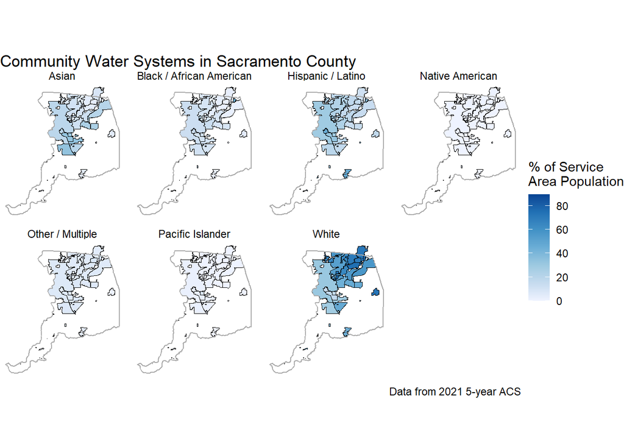

Figure 4: Portion of population of different racial/ethic groups served by each water system in the Sacramento County area

```r
plot_results_facet <- ggplot() +
    geom_sf(data = water_systems_sac_demographics_long,
            aes(fill = value),
            color = 'black') +
    geom_sf(data = counties_ca %>%
                filter(NAME == 'Sacramento'),
            color = 'darkgrey',
            linewidth = 0.5,
            fill = NA) +
    facet_wrap( ~ metric, ncol = 4) +
    scale_fill_distiller(palette = 'Blues', direction = 1) +
    labs(title = 'Community Water Systems in Sacramento County',
         fill = '% of Service\nArea Population',
         caption = paste0('Data from ', acs_year, ' 5-year ACS')) +
    theme_void()
plot_results_facet
```

Since the values for some groups are hard to distinguish, we can show the results for a single racial/ethnic group.

```r
group_plot <- 'Black / African American'
```

Figure 5 shows the results for the Black / African American racial/ethnic group.

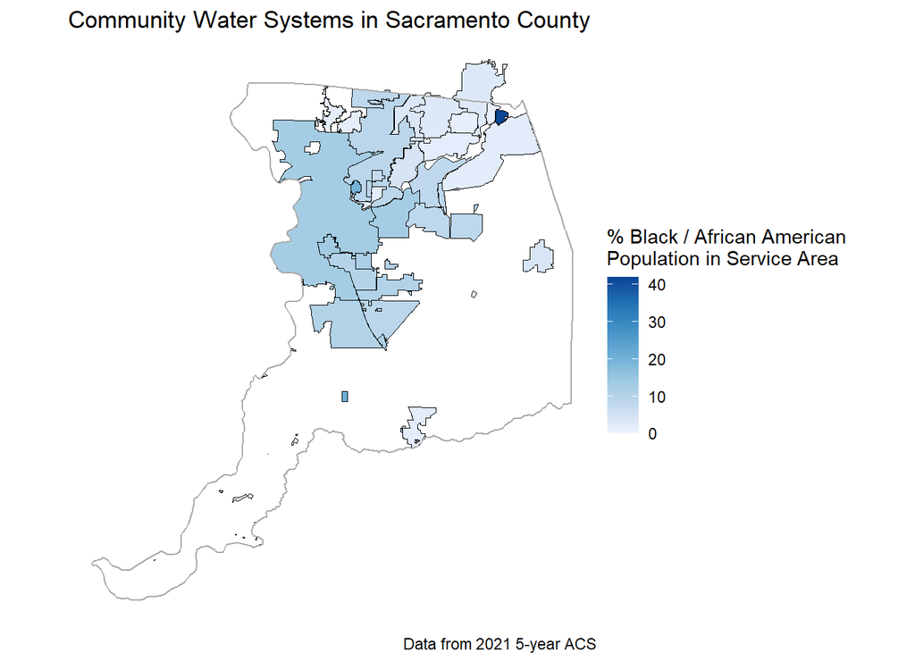

Figure 5: Portion of Black or African American residents served by each water system in the Sacramento County Area

```r
plot_results_1_group <- ggplot() +
    geom_sf(data = water_systems_sac_demographics_long %>%
                filter(metric == group_plot),
            aes(fill = value),
            color = 'black') +
    scale_fill_distiller(palette = 'Blues',
                         direction = 1) +
    geom_sf(data = counties_ca %>%
                filter(NAME == 'Sacramento'),
            color = 'darkgrey',
            linewidth = 0.5,
            fill = NA) +
    labs(title = 'Community Water Systems in Sacramento County',
         fill = paste0('% ', group_plot, '\nPopulation in Service Area'),
         caption = paste0('Data from ', acs_year, ' 5-year ACS')) +
    theme_void()
plot_results_1_group
```

As another example, we may want to look at the portion of all Non-White residents served by water systems, which is shown in Figure 6.

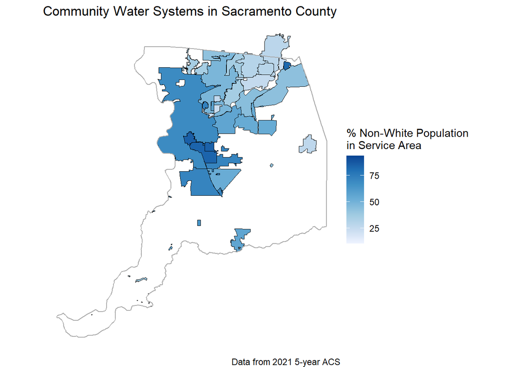

Figure 6: Portion of Non-White residents served by each water system in the Sacramento County Area

```r
plot_results_non_white <- ggplot() +
    geom_sf(data = water_systems_sac_demographics %>%
                mutate(pct_est_non_white = 100 - pct_est_white), # compute non-white portion of population for each water system
            aes(fill = pct_est_non_white),
            color = 'black') +
    scale_fill_distiller(palette = 'Blues',
                         direction = 1) +
    geom_sf(data = counties_ca %>%
                filter(NAME == 'Sacramento'),
            color = 'darkgrey',
            linewidth = 0.5,
            fill = NA) +
    labs(title = 'Community Water Systems in Sacramento County',
         fill = '% Non-White Population \nin Service Area',
         caption = paste0('Data from ', acs_year, ' 5-year ACS')) +
    theme_void()
plot_results_non_white
```

Alternatively, with the `tmap` package, we can show both the percent (blue color gradient) and count (size of circles) of the Non-White population in each water system’s service area, as in Figure 7.

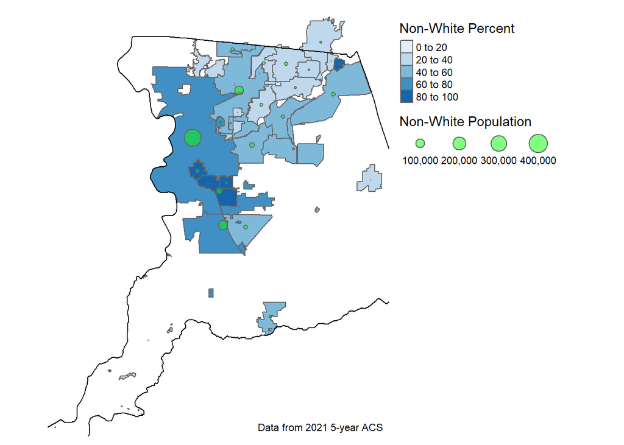

Figure 7: Portion and population of Non-White residents served by each water system in the Sacramento County Area

```r
t_map_pct_pop_nonwhite <-
    tm_shape(water_systems_sac_demographics %>%
                 mutate(pct_est_non_white = 100 - pct_est_white, # compute non-white portion of population for each water system
                        pop_est_non_white = pop_est_total - pop_est_white # compute total non-white population for each water system
                 )
    ) +
    tm_polygons(col = 'pct_est_non_white',
                palette = "Blues",
                title = 'Non-White Percent' #, legend.hist = TRUE
    ) +
    tm_bubbles(size = "pop_est_non_white",
               alpha = 0.5,
               col = "green",
               title.size = "Non-White Population") +
    tm_shape(counties_ca %>%
                 filter(NAME == 'Sacramento')) +
    tm_borders(col = 'black') +
    tm_layout(# main.title = "Non-White Population in Community Water Systems \nin Sacramento County",
        # main.title.size = 0.9
        frame = FALSE,
        legend.outside = TRUE
    ) +
    tm_credits(paste0('Data from ', acs_year, ' 5-year ACS'),
               position = c("RIGHT", "BOTTOM"))

t_map_pct_pop_nonwhite
```

Similarly, we can show both the percent Non-White population (blue color gradient) and median household income (size of circles) for each water system’s service area, as in Figure 8.

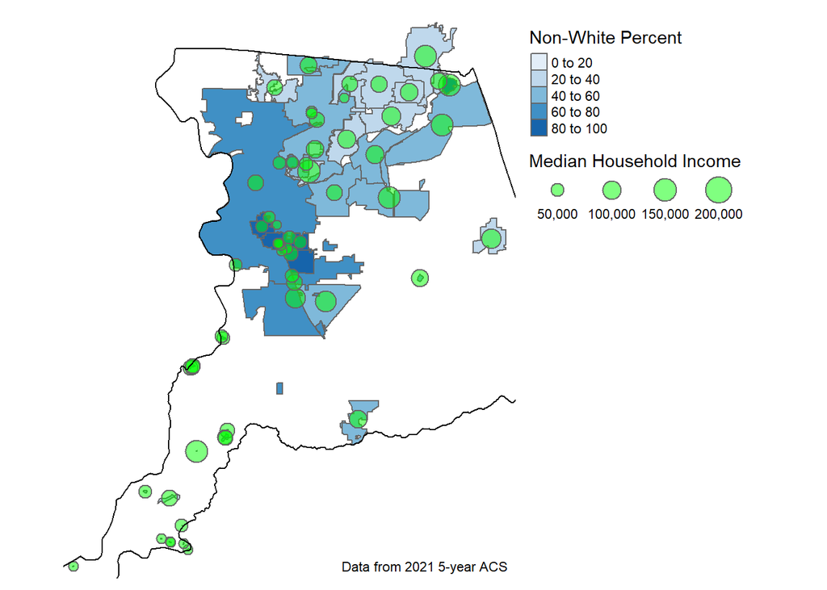

Figure 8: Portion of Non-White residents and median household income for each water system in the Sacramento County Area

```r
t_map_pct_nonwhite_medincome <-
    tm_shape(water_systems_sac_demographics %>%
                 mutate(pct_est_non_white = 100 - pct_est_white # compute non-white portion of population for each water system
                 )
    ) +
    tm_polygons(col = 'pct_est_non_white',
                palette = "Blues",
                title = 'Non-White Percent' #, legend.hist = TRUE
    ) +
    tm_bubbles(size = "med_hh_income_est",
               alpha = 0.5,
               col = "green",
               title.size = "Median Household Income"
    ) +
    tm_shape(counties_ca %>%
                 filter(NAME == 'Sacramento')) +
    tm_borders(col = 'black') +
    tm_layout(# main.title = "Non-White Population and Median Household Income \nin Community Water Systems in Sacramento County",
        # main.title.size = 0.9
        frame = FALSE,
        legend.outside = TRUE
    ) +
    tm_credits(paste0('Data from ', acs_year, ' 5-year ACS'),
               position = c("RIGHT", "BOTTOM"))

t_map_pct_nonwhite_medincome
```

We could also do a more detailed analysis of the relationships between some of the computed characteristics. For example, Figure 9 shows the relationship between median household income and percent non-white population for the water systems in this study.

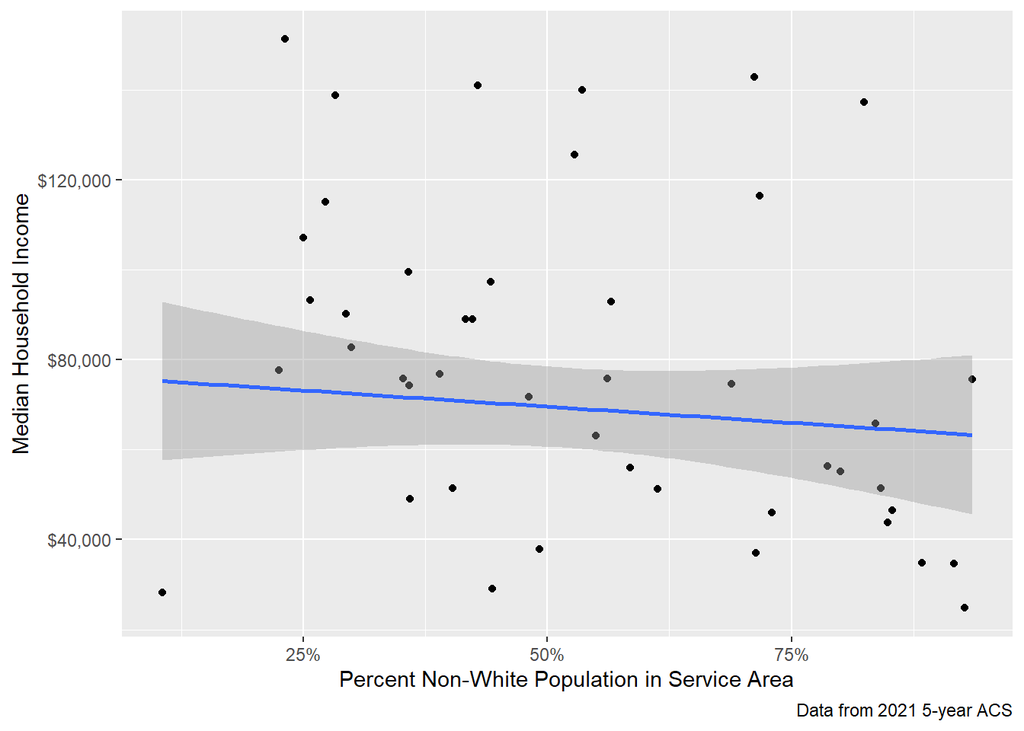

Figure 9: Portion of Non-White residents and median household income for water systems in the Sacramento County Area

```r
plot_results_scatter <- ggplot(data = water_systems_sac_demographics %>%
                                   mutate(pct_est_non_white = (100 - pct_est_white)/100), # compute non-white portion of population for each water system)
                               aes(x = pct_est_non_white,
                                   y = med_hh_income_est)) +
    geom_point() +
    # scale_fill_distiller(palette = 'Blues',
    #                      direction = 1) +
    geom_smooth(method = 'lm') +
    labs(title = NULL,
         caption = paste0('Data from ', acs_year, ' 5-year ACS'),
         x = 'Percent Non-White Population in Service Area',
         y = 'Median Household Income') +
    scale_y_continuous(labels = label_dollar()) +
    scale_x_continuous(labels = label_percent())
plot_results_scatter
```

### 5.4 Save Results

Once we’ve finished the computations and verified the outputs look reasonable, we can save the results to output files so they can be re-used and shared. The results can be saved in tabular (e.g., csv, excel) and/or spatial (e.g., shapefile, geopackage) formats, which may be helpful for different use cases. Note that you may need to think about exactly what variables to include in the output file(s) and how to format the output datasets (e.g., wide versus long format).

The chunk of code below (which is hidden by default), just tests to see whether any of the datasets to be saved have been changed since the previous version was saved. In general this is probably not needed for a typical workflow and can be ignored for most use cases – it is just used here to make rendering of this document a little more efficient.

```r
# compute hash for datasets to be saved (i.e., a unique identifier for each dataset), and compare against previous versions

## define file that stores hash (unique identifier for dataset)
hash_file <- here('02_data_results',
                  'dataset_hash.csv')

## compute hashes (unique identifier for datasets)
hash_current <- digest(object = water_systems_sac_demographics,
                       algo = 'md5')
hash_current_long <- digest(object = water_systems_sac_demographics_long,
                            algo = 'md5')
hash_table_current <- tibble(dataset = c('water_systems_sac_demographics', 'water_systems_sac_demographics_long'),
                             hash = c(hash_current, hash_current_long))

## get the previous hashes from file (if it exists), else create a new file to store the hashes
if (file.exists(hash_file)) {
    hash_table_previous <- read_csv(file = hash_file)
} else {
    file.create(hash_file)
    hash_table_previous <- tibble(dataset = c('water_systems_sac_demographics', 'water_systems_sac_demographics_long'),
                             hash = c('missing', 'missing'))
}

## if new hash is different from previous hash, set flag to update the output file (i.e., write a new version of the file)
file_update <- !identical(hash_table_current %>% filter(dataset == 'water_systems_sac_demographics') %>% pull(hash),
                          hash_table_previous %>% filter(dataset == 'water_systems_sac_demographics') %>% pull(hash))
file_update_long <- !identical(hash_table_current %>% filter(dataset == 'water_systems_sac_demographics_long') %>% pull(hash),
                               hash_table_previous %>% filter(dataset == 'water_systems_sac_demographics_long') %>% pull(hash))

## write current hashes to file (for comparison with future versions)
write_csv(x = hash_table_current,
          file = hash_file,
          append = FALSE)
```

#### 5.4.1 Tabular Dataset

The code below saves the tabular results to a csv file – note that this dataset is in the ‘wide’ format we originally produced the results in:

```r
if (file_update == TRUE) {
    write_csv(water_systems_sac_demographics %>%
                  st_drop_geometry(), # drop the spatial data since this is a tabular format
              file = here('02_data_results',
                          'water_system_demographics_sac.csv'))
}
```

For the tabular data, it might also be useful to save the data in the long/tidy format we developed above when making plots:

```r
if (file_update_long == TRUE) {
    write_csv(water_systems_sac_demographics_long %>%
                  st_drop_geometry(), # drop the spatial data since this is a tabular format
              file = here('02_data_results',
                          'water_system_demographics_sac_long.csv'))
}
```

#### 5.4.2 Spatial Dataset

To save the output in a geospatial format, it may be best to save the data in a wide format, so that all of the attribute data for each target area (water system) is in a single row along with its spatial data (i.e. the system boundary information). The code below saves the results – in wide format – to a geopackage file, which is a spatial file format that is similar to a shapefile.

```r
if (file_update == TRUE) {
    st_write(water_systems_sac_demographics,
             here('02_data_results',
                  'water_system_demographics_sac.gpkg'),
             append = FALSE)
}
```

### 5.5 Check – Manual Calculations

To check the interpolation obtained from the `aw_interpolate` function and demonstrate how it works, we can ‘manually’ perform the same types of weighted average calculation using lower level functions from the `sf` package. In this case, to keep the operations relatively simple, we’ll just perform the calculation for an individual water system, then check that calculated value against the results obtained from the `aw_interpolate` function. However, the process is the similar for the other suppliers used in this example.

```r
# pick a system to check
system_check <- 'CARMICHAEL WATER DISTRICT'
```

#### 5.5.1 Total Population

```r
# get the total estimated population for this supplier from above
pop_weighted_interp <- water_systems_sac_demographics %>%
    filter(WATER_SY_1 == system_check) %>%
    pull(pop_est_total)
```

In this case, we’ll check the calculation for the water system: `CARMICHAEL WATER DISTRICT`. The estimated population for this system using the areal interpolation above (Section 5.2) was: `39,321`.

To perform the ‘manual’ calculation, we’ll first get the portions of the census units that intersect the target water system’s service area. They are shown in red in Figure 10 below (the water system boundary is shown in black, and all census units which overlap the system are shown with a randomly chosen fill color).

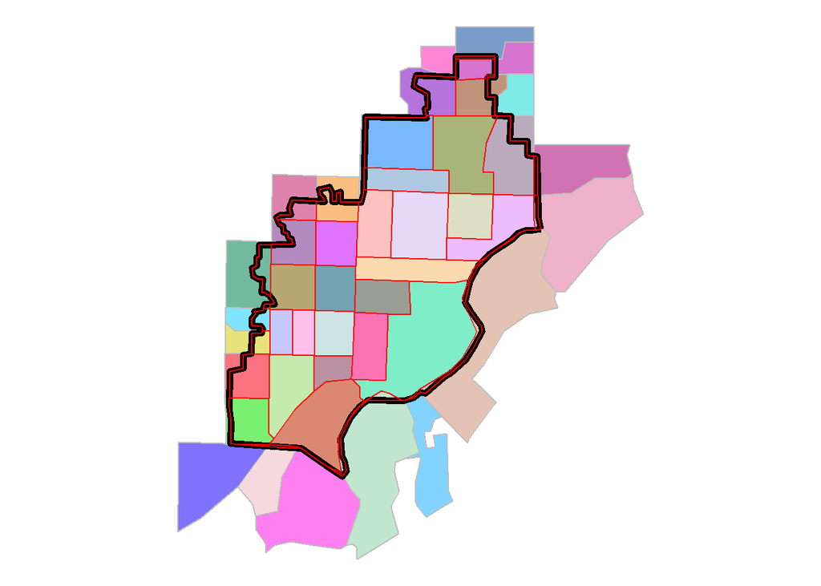

Figure 10: Portions of census units (red) intersecting the water system service area (black).

```r
# get portion of census units that intersect the system area ----
interpolate_manual_pop <- st_intersection(census_data_acs %>%
                                              mutate(total_area = st_area(.)),
                                          water_systems_sac %>%
                                              filter(WATER_SY_1 == system_check))

# make a plot to check the intersection
## plot census units that overlap the system area
plot_manual_check <- ggplot() +
    geom_sf(data = census_data_acs %>%
                st_filter(water_systems_sac %>%
                              filter(WATER_SY_1 == system_check)),
            aes(fill = GEOID, alpha = 0.8),
            # fill = alpha('blue', 0.8),
            color = 'grey',
            linewidth = 0.5,
            show.legend = FALSE) +
    scale_fill_manual(values = unname(pal)) +
    geom_sf(data = water_systems_sac %>%
                filter(WATER_SY_1 == system_check),
            fill = NA,
            color = alpha('black', 1),
            linewidth = 2) +
    geom_sf(data = interpolate_manual_pop,
            fill = NA,
            color = 'red',
            linewidth = 0.5) +
    theme_void()

# show the plot
plot_manual_check
```

Then we’ll estimate the population within each of those intersecting portions of the census units by computing an area weighted population. The area weighted population is computed by multiplying the total population of the census unit by the percent of that census unit’s area that overlaps the water supplier’s service area.

```r
interpolate_manual_pop <- interpolate_manual_pop %>%
    mutate(intersect_area = st_area(.)) %>%
    mutate(weight = drop_units(intersect_area / total_area)) %>%
    mutate(pop_weighted = pop_total * weight)

glimpse(interpolate_manual_pop %>%
            select(GEOID, NAME, pop_total,
                   total_area, intersect_area, weight,
                   pop_weighted))
```

```
Rows: 43
Columns: 8
$ GEOID          <chr> "060670079043", "060670078012", "060670058041", "060670…
$ NAME           <chr> "Block Group 3, Census Tract 79.04, Sacramento County, …
$ pop_total      <dbl> 1167, 1842, 963, 2185, 751, 660, 2288, 2435, 761, 1992,…
$ total_area     [m^2] 573602.4 [m^2], 1214861.6 [m^2], 742430.6 [m^2], 974344…
$ intersect_area [m^2] 436050.8824 [m^2], 1214861.6295 [m^2], 17898.9277 [m^2]…
$ weight         <dbl> 0.760197080, 1.000000000, 0.024108554, 0.221407985, 1.0…
$ pop_weighted   <dbl> 887.1499923, 1842.0000000, 23.2165377, 483.7764476, 751…
$ geometry       <GEOMETRY [m]> POLYGON ((-113200.2 71785.2..., POLYGON ((-113…
```

The weighted average population for the water system is the sum of the area weighted population within each of the intersecting portions of the census units.

```r
# this should be the same as the interpolated result
pop_est_weighted_manual <- interpolate_manual_pop %>%
    pull(pop_weighted) %>%
    sum() %>%
    round(digits = 0)
pop_est_weighted_manual
```

```
[1] 39321
```

So, as a final check, the ‘manually’ calculated total population for `CARMICHAEL WATER DISTRICT` is `39,321`, and the value obtained from the `aw_interpolate` function above was `39,321`.

#### 5.5.2 Median Household Income

The methodology for calculating a variable like median household income, which doesn’t represent a count (unlinke the population example in Section 5.5.1 above) is a bit different. Computations on variables which represent averages, medians, percentages, densities, etc. are known as spatially intensive operations (see [this documenation](https://chris-prener.github.io/areal/articles/areal-weighted-interpolation.html#extensive-and-intensive-interpolations) for more information).

```r
# get the estimated median household income for this supplier from above
med_hh_income_interp <- water_systems_sac_demographics %>%
    filter(WATER_SY_1 == system_check) %>%
    pull(med_hh_income_est)
```

In this case, we’ll check the calculation for the water system: `CARMICHAEL WATER DISTRICT`. The estimated median household income for this system using the areal interpolation above (Section 5.2) was: `$99,561`.

As with the population calculation, we’ll first get the portions of the census units that intersect the target water system’s service area. They are shown in red in Figure 10 above.

```r
interpolate_manual_hh_inc <- st_intersection(census_data_acs,
                                             water_systems_sac %>%
                                                 filter(WATER_SY_1 == system_check))
```

Next, we need to account for census units where median household income is missing (missing values are represented as `NA` in our census dataset), in this case by removing them from the calculation (like we did above in Section 5.2.1) – in this case that’s 1 census unit(s) with missing median household income data. Note that simply removing census units with missing data could impact the quality of our calculations if there are significant portions of the service area covered by census units that contain missing values for this variable, and in a real-world analysis it may be necessary to do additional work to investigate and make adjustments to account for these missing values. However, in this case we’ll just drop them for simplicity.

```r
sum(is.na(interpolate_manual_hh_inc$med_hh_income))
```

```
[1] 1
```

```r
interpolate_manual_hh_inc <- interpolate_manual_hh_inc %>%
    filter(!is.na(med_hh_income))
```

Then we’ll compute the combined area of the portions of the census units that intersect the water system area.

```r
# get portion of census units that intersect the system area ----
interpolate_manual_hh_inc <- interpolate_manual_hh_inc %>%
    mutate(intersect_area = st_area(.))

# compute combined area of all census segments that intersect the system area
total_intersection_area <- sum(interpolate_manual_hh_inc$intersect_area)
```

Next we’ll a compute weights for the census units that intersect the water system area. The weight for a given census unit is calculated as the area of that census unit that intersects the water system area, divided by the combined area of the portions of the census units that intersect the water system area.

```r
# compute weight
interpolate_manual_hh_inc <- interpolate_manual_hh_inc %>%
    mutate(total_intersection_area = total_intersection_area) %>%
    mutate(weight = drop_units(intersect_area / total_intersection_area))
```

The weights should sum to 1.

```r
# check - the weights should sum to 1
sum(interpolate_manual_hh_inc$weight) == 1
```

```
[1] TRUE
```

Then we can compute the weighted median household income for each census unit, which is just the median household income for that census unit multiplied by the weight calculated above.

```r
interpolate_manual_hh_inc <- interpolate_manual_hh_inc %>%
    mutate(med_hh_inc_weighted = med_hh_income * weight)

glimpse(interpolate_manual_hh_inc %>%
            select(GEOID, NAME, med_hh_income,
                   intersect_area, total_intersection_area, weight,
                   med_hh_inc_weighted))
```

```
Rows: 42
Columns: 8
$ GEOID                   <chr> "060670079043", "060670078012", "060670058041"…
$ NAME                    <chr> "Block Group 3, Census Tract 79.04, Sacramento…
$ med_hh_income           <dbl> 107734, 64307, 149306, 91536, 96691, 93920, 42…
$ intersect_area          [m^2] 436050.8824 [m^2], 1214861.6295 [m^2], 17898.9…
$ total_intersection_area [m^2] 21404686 [m^2], 21404686 [m^2], 21404686 [m^2]…
$ weight                  <dbl> 0.02037174820, 0.05675680571, 0.00083621537, 0…
$ med_hh_inc_weighted     <dbl> 2194.729920, 3649.859905, 124.851972, 922.5475…
$ geometry                <GEOMETRY [m]> POLYGON ((-113200.2 71785.2..., POLYG…
```

The area weighted median household income estimate for the water system is then the sum of the weighted median household income for each of the intersecting census units (remember that census units where median household income is missing – i.e., `NA` – have already been removed above).

```r
# this should be the same as the interpolated result
med_hh_income_est_weighted_manual <- interpolate_manual_hh_inc %>%
    pull(med_hh_inc_weighted) %>%
    sum() %>%
    round(digits = 0)
med_hh_income_est_weighted_manual
```

```
[1] 99561
```

So, as a final check, the manually calculated median household income for `CARMICHAEL WATER DISTRICT` is `$99,561`, and the value obtained from the `aw_interpolate` function was `$99,561`.

#### 5.5.3 Systems with Zero Estimated Population

For some water systems, the estimated population using the areal interpolation above (Section 5.2) was zero, and it may be useful to look at an example to see what’s going on with one of those cases.

```r
# pick a system to check
system_check_zero <- water_systems_sac_demographics %>%
    filter(pop_est_total == 0) %>%
    arrange(WATER_SY_1) %>%
    slice(1) %>%
    pull(WATER_SY_1)

# get the total estimated population for this system from above
pop_weighted_interp_zero <- water_systems_sac_demographics %>%
    filter(WATER_SY_1 == system_check_zero) %>%
    pull(pop_est_total)
```

In this case, we’ll check the calculation for the water system: `B & W RESORT MARINA`. The estimated population for this system using the areal weighted interpolation with the `aw_interpolate` function above (Section 5.2) was: `0`.

To check this result, we’ll first get the portions of the census units that intersect the target water system’s service area, as was done for the other ‘manual’ calculations above. This is shown in Figure 11 below, with the water system boundary is shown in black, census unit(s) overlapping the water system shown in grey, and intersecting portion(s) of the census unit(s) shown in red.

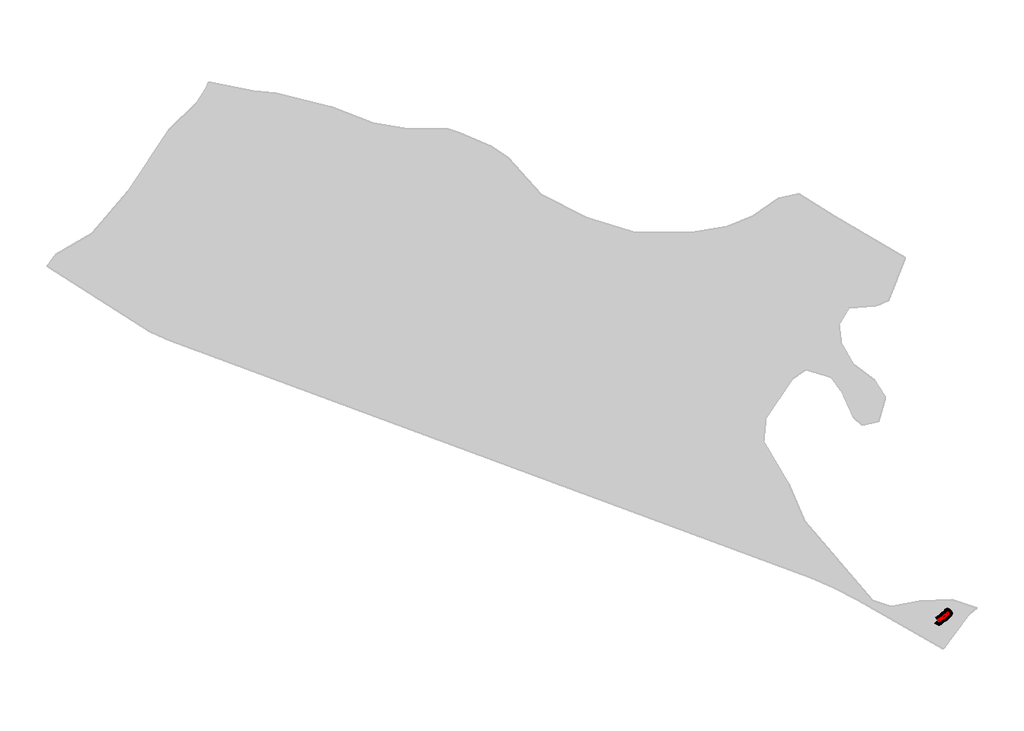

Figure 11: Portions of census units (red) intersecting the water system service area (black).

```r
# get portion of census units that intersect the system area ----
interpolate_manual_zero <- st_intersection(census_data_acs %>%
                                               mutate(total_area = st_area(.)),
                                           water_systems_sac %>%
                                               filter(WATER_SY_1 == system_check_zero))

# make a plot to check the intersection
## plot census units that overlap the system area
plot_manual_check_zero <- ggplot() +
    geom_sf(data = census_data_acs %>%
                st_filter(water_systems_sac %>%
                              filter(WATER_SY_1 == system_check_zero)),
            fill = alpha('grey', 0.8),
            color = 'grey',
            linewidth = 0.5,
            show.legend = FALSE) +
    geom_sf(data = water_systems_sac %>%
                filter(WATER_SY_1 == system_check_zero),
            fill = NA,
            color = alpha('black', 1),
            linewidth = 2) +
    geom_sf(data = interpolate_manual_zero,
            fill = NA,
            color = 'red',
            linewidth = 0.5) +
    theme_void()

# show the plot
plot_manual_check_zero
```

Then we’ll estimate the population within each of those intersecting portions of the census units by computing an area weighted population (as was done above in Section 5.5.1) .

```r
interpolate_manual_zero <- interpolate_manual_zero %>%
    mutate(intersect_area = st_area(.)) %>%
    mutate(weight = drop_units(intersect_area / total_area)) %>%
    mutate(pop_weighted = pop_total * weight)

glimpse(interpolate_manual_zero %>%
            select(GEOID, NAME, pop_total,
                   total_area, intersect_area, weight,
                   pop_weighted))
```

```
Rows: 1
Columns: 8
$ GEOID          <chr> "060670098001"
$ NAME           <chr> "Block Group 1, Census Tract 98, Sacramento County, Cal…
$ pop_total      <dbl> 822
$ total_area     [m^2] 22669410 [m^2]
$ intersect_area [m^2] 2523.735 [m^2]
$ weight         <dbl> 0.0001113278
$ pop_weighted   <dbl> 0.09151145
$ geometry       <POLYGON [m]> POLYGON ((-138282.2 13643.2...
```

The weighted average population for the water system is the sum of the area weighted population within each of the intersecting portions of the census unit(s).

```r
# this should be the same as the interpolated result
pop_est_weighted_manual_zero <- interpolate_manual_zero %>%
    pull(pop_weighted) %>%
    sum()
pop_est_weighted_manual_zero
```

```
[1] 0.09151145
```

In this case, the (un-rounded) ‘manually’ calculated total population for `B & W RESORT MARINA` is `0.09151145` (for reference, the rounded value obtained from the `aw_interpolate` function was `0)`. From the Figure 11 above, you can see that the service area reported for this system is very small, only covering a small fraction of a single census unit, resulting in a population estimate that is very low. In this case, it could be that the system area was drawn incorrectly (i.e., maybe it doesn’t really depict the entire service area), in which case the reported service area should be revised. Or, it’s possible that the population within the given census unit is very un-evenly distributed and instead there’s a relatively high density population cluster in the depicted service area, in which case a more sophisticated method than an area-weighted average should be used (e.g., maybe consider the density of buildings, roads, and/or other features associated with inhabited areas).

## 6 Alternative Computation Methods

This section is in progress…

### 6.1 Population Weighted Average

This section is in progress…

This could be used for estimating certain types of metrics (e.g., median household income, CalEnviroScreen scores), using known or estimated population distributions (i.e., not used directly to determine population count in a given area).

There may be a few ways to do this:

1. ‘Manual’ calculation – e.g., estimate population of overlapping census units (using total population multiplied by % of the census unit within the target area), then use those derived populations as weights (rather than the area of overlap)
2. Use the [`interpolate_pw`](https://walker-data.com/tidycensus/reference/interpolate_pw.html) function from the `tidycensus` package (I think this is based on the methodology described [here](https://pro.arcgis.com/en/pro-app/latest/help/analysis/business-analyst/data-apportionment-and-layers.htm) but need to investigate further).

As a rough example of option #2:

First get 2020 census population by census block (not strictly necessary, but this is the most spatially granular census population data available):

```r
# get census data
census_data_blocks <- get_decennial(geography = 'block', # can be 'block', 'block group', 'tract', 'county', etc.
                                    state = 'CA',
                                    county = counties_list,
                                    year = 2020,
                                    variables = c(
                                        'pop_total' = 'P2_001N'
                                    ),
                                    output = 'wide', # can be 'wide' or 'tidy'
                                    geometry = TRUE,
                                    cache_table = TRUE)
```

```
Using the PL 94-171 Redistricting Data Summary File
```

Then interpolate:

```r
results_interp_popwt <- interpolate_pw(from = census_data_filter %>%
                                           st_transform(crs_projected) %>%
                                           filter(!is.na(med_hh_income)) %>%
                                           select(med_hh_income),
                                       to = water_systems_sac %>%
                                           st_transform(crs_projected),
                                       to_id = 'WATER_SY_1',
                                       extensive = FALSE,
                                       weights = census_data_blocks %>%
                                           st_transform(crs_projected),
                                       # weight_placement = 'surface',
                                       weight_column = 'pop_total') %>%
    rename(med_hh_income_est_popwt = med_hh_income) # rename results field
```

```r
results_interp_popwt <- results_interp_popwt %>%
    left_join(water_systems_sac %>%
                  st_drop_geometry() %>%
                  select(SERVICE_CO, POPULATION, WATER_SY_1),
              by = 'WATER_SY_1')

glimpse(results_interp_popwt)
```

```
Rows: 62
Columns: 5
$ WATER_SY_1              <chr> "HOOD WATER MAINTENCE DIST [SWS]", "MC CLELLAN…
$ med_hh_income_est_popwt <dbl> 51250.00, 37833.00, 63076.00, NA, 34669.00, NA…
$ SERVICE_CO              <dbl> 82, 199, 34, 64, 128, 83, 28, 50, 164, 5684, 1…
$ POPULATION              <dbl> 100, 700, 40, 150, 256, 150, 32, 100, 350, 180…
$ geometry                <MULTIPOLYGON [m]> MULTIPOLYGON (((-132703 403..., M…
```

Note that not all water systems get an estimated value using this method (even if `NA` values are removed from the source data) – a total of 17 systems are missing results with this method, which tend to be the smallest water systems.

Figure 12 shows a comparison (note that each plot only includes systems that have a population weighted result, so the results look a little different than the scatter plot above in Figure 9 showing all systems). Also, note that these figures may not be that helpful by themselves for this example, but just provide an example of how different approaches could be compared to check whether or not the results are sensitive to the methodology used in any significant way.

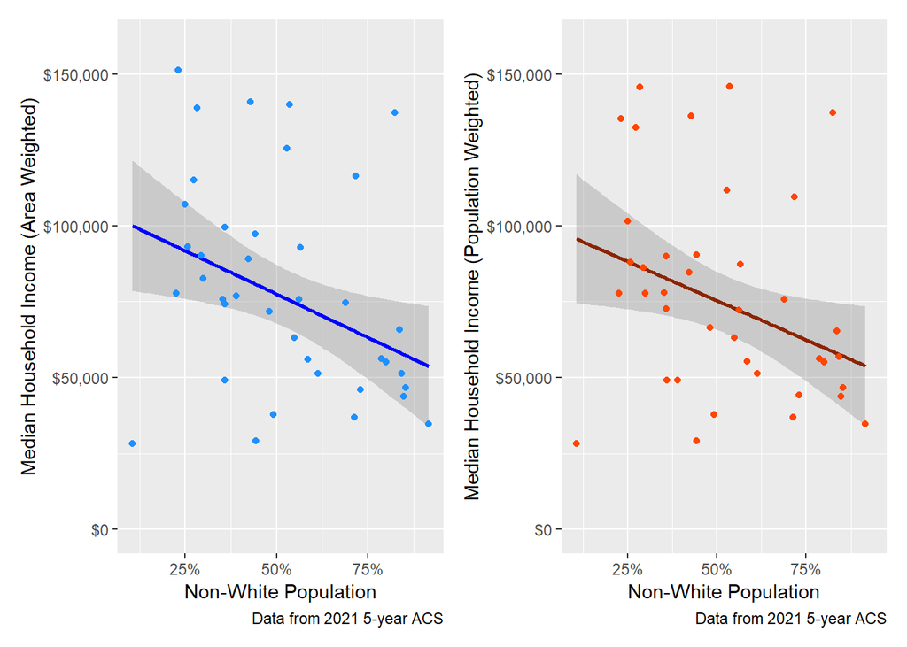

Figure 12: Relationship between Non-White population and median household income for water systems in the Sacramento County Area, using an area-weighted (left, blue) versus population-weighted approach (right, orange) approach to deterime median household income

```r
# Plot area weighted results
plot_results_scatter_areawt <- ggplot(data = water_systems_sac_demographics %>%
                                           mutate(pct_est_non_white = (100 - pct_est_white)/100) %>% # compute non-white portion of population for each water system)
                                           left_join(results_interp_popwt %>% st_drop_geometry(),
                                                     by = 'WATER_SY_1') %>% # join the population weighted estimate
                                          filter(!is.na(med_hh_income_est_popwt)), # drop results for systems where the pop weighted result is missing, for consistency
                                       aes(x = pct_est_non_white,
                                           y = med_hh_income_est)) +
    geom_smooth(method = 'lm', color = 'blue') +
    geom_point(color = 'dodgerblue') +
    labs(title = NULL,
         caption = paste0('Data from ', acs_year, ' 5-year ACS'),
         x = 'Non-White Population',
         y = 'Median Household Income (Area Weighted)') +
    scale_y_continuous(labels = label_dollar(), limits = c(0, 160000)) +
    scale_x_continuous(labels = label_percent())



# Plot population weighted results
plot_results_scatter_popwt <- ggplot(data = water_systems_sac_demographics %>%
                                           mutate(pct_est_non_white = (100 - pct_est_white)/100) %>% # compute non-white portion of population for each water system)
                                           left_join(results_interp_popwt %>% st_drop_geometry(),
                                                     by = 'WATER_SY_1'), # join the population weighted estimate
                                       aes(x = pct_est_non_white,
                                           y = med_hh_income_est_popwt)) +
    geom_smooth(method = 'lm', color = 'orangered4') +
    geom_point(color = 'orangered') +
    labs(title = NULL,
         caption = paste0('Data from ', acs_year, ' 5-year ACS'),
         x = 'Non-White Population',
         y = 'Median Household Income (Population Weighted)') +
    scale_y_continuous(labels = label_dollar(), limits = c(0, 160000)) +
    scale_x_continuous(labels = label_percent())

# combine the two plots (side by side)
plot_results_scatter_areawt + plot_results_scatter_popwt
```

Figure 13 shows a more direct comparison of the population weighted approach with the original area-weighted approach.

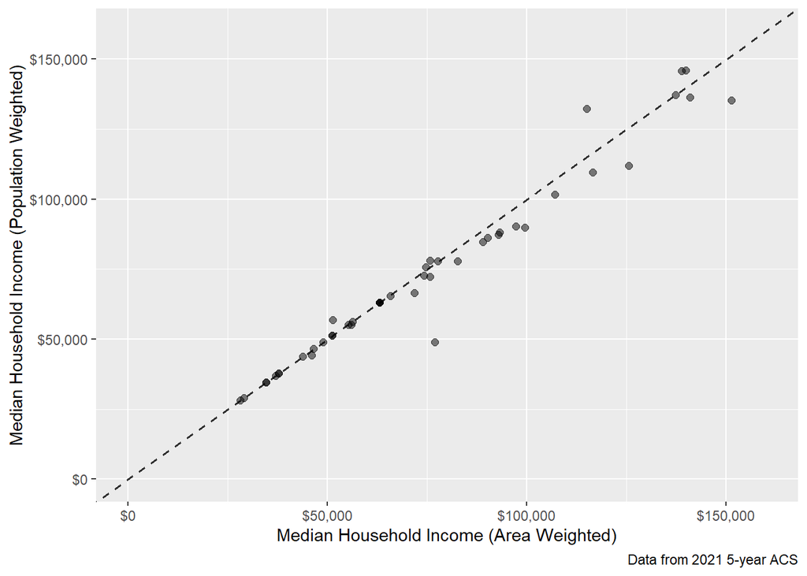

Figure 13: Relationship between median household income for water systems in the Sacramento County Area estimated from U.S. Census Bureau data using an area-weighted versus population-weighted estimate

```r
plot_results_scatter_compare <- ggplot(data = water_systems_sac_demographics %>%
                                           left_join(results_interp_popwt %>% st_drop_geometry(),
                                                     by = 'WATER_SY_1'), # join the population weighted estimate
                                       aes(x = med_hh_income_est,
                                           y = med_hh_income_est_popwt)) +
    geom_abline(slope = 1, intercept = 0, color = 'black', linetype = 'dashed', size = 0.6, alpha = 0.8) +
    geom_point(alpha = 0.5, size = 2) +
    labs(title = NULL,
         caption = paste0('Data from ', acs_year, ' 5-year ACS'),
         x = 'Median Household Income (Area Weighted)',
         y = 'Median Household Income (Population Weighted)') +
    scale_y_continuous(labels = label_dollar(), limits = c(0, 160000)) +
    scale_x_continuous(labels = label_dollar(), limits = c(0, 160000))

plot_results_scatter_compare
```

## 7 Working with Other (Non-Census) Source Data

This section is in progress…

### 7.1 CalEnviroScreen

This section is in progress…

## References

Parry, Josiah. 2023. “Arcgislayers: An r Interface for ArcGIS REST Services.”

Pebesma, Edzer, and Roger Bivand. 2023. “Spatial Data Science: With Applications in r.” https://doi.org/10.1201/9780429459016.

Prener, Christopher, Revord, and Charles. 2019. “areal: An R package for areal weighted interpolation.” *Journal of Open Source Software* 4 (37). https://doi.org/10.21105/joss.01221.

R Core Team. 2023. *R: A Language and Environment for Statistical Computing*. Vienna, Austria: R Foundation for Statistical Computing. https://www.R-project.org/.

Walker, Kyle. 2023a. “Tigris: Load Census TIGER/Line Shapefiles.” https://CRAN.R-project.org/package=tigris.

———. 2023b. “Analyzing US Census Data,” January. https://doi.org/10.1201/9780203711415.

Walker, Kyle, and Matt Herman. 2023. “Tidycensus: Load US Census Boundary and Attribute Data as ’Tidyverse’ and ’Sf’-Ready Data Frames.” https://CRAN.R-project.org/package=tidycensus.

Wickham, Hadley, Mara Averick, Jennifer Bryan, Winston Chang, Lucy D’Agostino McGowan, Romain François, Garrett Grolemund, et al. 2019. “Welcome to the Tidyverse” 4: 1686. https://doi.org/10.21105/joss.01686.